# Logbook_Jasper

Jasper Jonker

2025-04-23

For our school project were are gone do an research like (Fibroblast-derived osteoglycin promotes epithelial cell repair)[https://pmc.ncbi.nlm.nih.gov/articles/PMC11937367/]. They are very specific and we are gone a look more global. I will look at the pathway analysis of the transcription.

For this i will use fgsea that is an tool that can be used for this kind of analysis.

First we are going to install it. That do we as follow:

```r
if (!require("BiocManager", quietly = TRUE))
    install.packages("BiocManager")

BiocManager::install("fgsea")
```

```r
if (!requireNamespace("BiocManager", quietly = TRUE))
    install.packages("BiocManager")
BiocManager::install("org.Mm.eg.db")
```

After this we read the library in:

```r
library(fgsea)
library(pathview)
library(data.table)
library(ggplot2)
library(DESeq2)
library(clusterProfiler)
library(msigdbr)
library(dplyr)
library(ggfortify)
library(org.Mm.eg.db)
library(org.Hs.eg.db)
library("vsn")
```

After this i am going to use the example data to look how it all works.

# oefen

```r
data(examplePathways)
data(exampleRanks)
```

```r
fgseaRes <- fgsea(pathways = examplePathways,
                  stats    = exampleRanks,
                  minSize  = 15,
                  maxSize  = 500)
```

```r
fgseaRes <- fgsea(pathways = examplePathways,
                  stats    = exampleRanks,
                  eps      = 0.0,
                  minSize  = 15,
                  maxSize  = 500)
```

[figure not shown]

```r
plotEnrichment(examplePathways[["5990980_Cell_Cycle"]],
               exampleRanks) + labs(title="Programmed Cell Death")
```

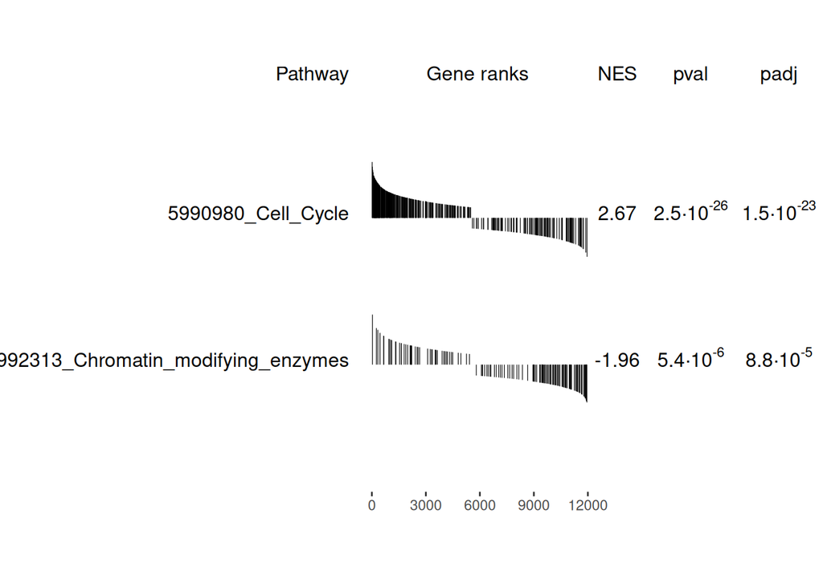

```r
topPathwaysUp <- fgseaRes[ES > 0][head(order(pval), n=1), pathway]
topPathwaysDown <- fgseaRes[ES < 0][head(order(pval), n=1), pathway]
topPathways <- c(topPathwaysUp, rev(topPathwaysDown))
plotGseaTable(examplePathways[topPathways], exampleRanks, fgseaRes,
              gseaParam=0.5)
```

## Over-Representation Analysis

```r
data("gcSample") # data for examples
```

```r
# Need to remove duplicates for the examples
all_genes <- unlist(gcSample)
universe <- all_genes[Biobase::isUnique(all_genes)] # all unique genes

# List with only unique genes
gcUnique <- lapply(gcSample, function(group_i) {
  group_i[group_i %in% universe]
})
```

```r
# MSigDB R package)
msigdbr::msigdbr_collections() # available collections
```

```
## # A tibble: 25 × 4
##    gs_collection gs_subcollection  gs_collection_name               num_genesets
##    <chr>         <chr>             <chr>                                   <int>
##  1 C1            ""                Positional                                302
##  2 C2            "CGP"             Chemical and Genetic Perturbati…         3494
##  3 C2            "CP"              Canonical Pathways                         19
##  4 C2            "CP:BIOCARTA"     BioCarta Pathways                         292
##  5 C2            "CP:KEGG_LEGACY"  KEGG Legacy Pathways                      186
##  6 C2            "CP:KEGG_MEDICUS" KEGG Medicus Pathways                     658
##  7 C2            "CP:PID"          PID Pathways                              196
##  8 C2            "CP:REACTOME"     Reactome Pathways                        1736
##  9 C2            "CP:WIKIPATHWAYS" WikiPathways                              830
## 10 C3            "MIR:MIRDB"       miRDB                                    2377
## # ℹ 15 more rows
```

```r
# Subset to Human GO-BP sets
BP_db <- msigdbr(species = "Homo sapiens",
                 category = "C5", subcategory = "GO:BP")
head(BP_db)
```

```
## # A tibble: 6 × 23
##   gene_symbol ncbi_gene ensembl_gene db_gene_symbol db_ncbi_gene db_ensembl_gene
##   <chr>       <chr>     <chr>        <chr>          <chr>        <chr>
## 1 AASDHPPT    60496     ENSG0000014… AASDHPPT       60496        ENSG00000149313
## 2 ALDH1L1     10840     ENSG0000014… ALDH1L1        10840        ENSG00000144908
## 3 ALDH1L2     160428    ENSG0000013… ALDH1L2        160428       ENSG00000136010
## 4 MTHFD1      4522      ENSG0000010… MTHFD1         4522         ENSG00000100714
## 5 MTHFD1L     25902     ENSG0000012… MTHFD1L        25902        ENSG00000120254
## 6 BOLA2       552900    ENSG0000018… BOLA2          552900       ENSG00000183336
## # ℹ 17 more variables: source_gene <chr>, gs_id <chr>, gs_name <chr>,
## #   gs_collection <chr>, gs_subcollection <chr>, gs_collection_name <chr>,
## #   gs_description <chr>, gs_source_species <chr>, gs_pmid <chr>,
## #   gs_geoid <chr>, gs_exact_source <chr>, gs_url <chr>, db_version <chr>,
## #   db_target_species <chr>, entrez_gene <chr>, gs_cat <chr>, gs_subcat <chr>
```

```r
# Convert to a list of gene sets
BP_conv <- unique(BP_db[, c("entrez_gene", "gs_exact_source")])
BP_list <- split(x = BP_conv$entrez_gene, f = BP_conv$gs_exact_source)
# First ~6 IDs of first 3 terms
lapply(head(BP_list, 3), head)
```

```
## $`GO:0000002`
## [1] "10000"  "131474" "1763"   "9093"   "2021"   "3980"
##
## $`GO:0000012`
## [1] "200558" "54840"  "2074"   "1161"   "3981"   "142"
##
## $`GO:0000018`
## [1] "25"     "60"     "86"     "10097"  "126549" "200558"
```

```r
## Cluster GO-BP ORA with fgsea package
# For each cluster i, perform ORA
fgsea_ora <- lapply(seq_along(gcUnique), function(i) {
  fora(pathways = BP_list,
       genes = gcUnique[[i]], # genes in cluster i
       universe = universe, # all genes
       minSize = 15,
       maxSize = 500) %>%
    mutate(cluster = names(gcUnique)[i]) # add cluster column
}) %>%
  data.table::rbindlist() %>% # combine tables
  filter(padj < 0.05) %>%
  arrange(cluster, padj) %>%
  # Add additional columns from BP_db
  left_join(distinct(BP_db, gs_subcat, gs_exact_source,
                     gs_name, gs_description),
            by = c("pathway" = "gs_exact_source")) %>%
  # Reformat descriptions
  mutate(gs_name = sub("^GOBP_", "", gs_name),
         gs_name = gsub("_", " ", gs_name))

# First 6 rows
head(fgsea_ora)
```

```
##       pathway         pval        padj foldEnrichment overlap  size
##        <char>        <num>       <num>          <num>   <int> <int>
## 1: GO:0007267 2.256698e-05 0.037322954       1.925199      40   233
## 2: GO:0045666 4.327299e-05 0.037322954       5.277311       8    17
## 3: GO:0006754 8.172229e-06 0.009614126       4.001214      12    24
## 4: GO:0015986 1.114681e-05 0.009614126       4.191748      11    21
## 5: GO:0022900 7.265561e-05 0.025305396       3.027945      14    37
## 6: GO:0042773 8.683660e-05 0.025305396       3.311349      12    29
##    overlapGenes cluster gs_subcat                                       gs_name
##          <list>  <char>    <char>                                        <char>
## 1: 6833, 47....      X3     GO:BP                           CELL CELL SIGNALING
## 2: 652, 655....      X3     GO:BP POSITIVE REGULATION OF NEURON DIFFERENTIATION
## 3: 4705, 46....      X7     GO:BP                      ATP BIOSYNTHETIC PROCESS
## 4: 4705, 46....      X7     GO:BP      PROTON MOTIVE FORCE DRIVEN ATP SYNTHESIS
## 5: 1329, 15....      X7     GO:BP                      ELECTRON TRANSPORT CHAIN
## 6: 1329, 15....      X7     GO:BP      ATP SYNTHESIS COUPLED ELECTRON TRANSPORT
##                                                                                                                                                                                                                                                                                                          …
##                                                                                                                                                                                                                                                                                                          …
## 1: Any process that mediates the transfer of information from one cell to another. This process includes signal transduction in the receiving cell and, where applicable, release of a ligand and any processes that actively facilitate its transport and presentation to the receiving cell. Examples i…
## 2:                                                                                                                                                                                                                                                                                                Any pro…
## 3:                                                                                                                                                                                                                       The chemical reactions and pathways resulting in the formation of ATP, adenosine…
## 4:                                                                                                                                                                                                                                                             The transport of protons across a membrane…
## 5:                                                                                                                                                                                                                         A process in which a series of electron carriers operate together to transfer …
## 6:                                                                                                                                                                                                                                                    The transfer of electrons through a series of elect…
```

# Pca

```r
data <- read.csv("../data/GSE271272_rawcounts.csv", row.names = 1)
head(data)
```

```
##               M1_ctrl_Epcam M2_ctrl_Epcam M3_ctrl_Epcam M4_ctrl_Epcam
## 0610009B22Rik           266            41            79            46
## 0610010K14Rik            21             3             3             1
## 0610012G03Rik           276            41            93            74
## 0610030E20Rik           416            88           132            84
## 0610038B21Rik            16             1             4             9
## 0610040J01Rik           765           144           236           120
##               M1_EVs_Epcam M2_EVs_Epcam M3_EVs_Epcam M4_EVs_Epcam M1_SFs_Epcam
## 0610009B22Rik          100           59          171          277          198
## 0610010K14Rik            7            2           17           24           19
## 0610012G03Rik           96          113          273          304          254
## 0610030E20Rik          163          106          372          494          443
## 0610038B21Rik            3            1            6            6           12
## 0610040J01Rik          221          170          584          661          692
##               M2_SFs_Epcam M3_SFs_Epcam M4_SFs_Epcam M1_OGN_Epcam M2_OGN_Epcam
## 0610009B22Rik           14           84           73           66           78
## 0610010K14Rik            2            3            5            6            5
## 0610012G03Rik           30           89          118          118           94
## 0610030E20Rik           36          188          178          161          129
## 0610038B21Rik            1            4            7            2            4
## 0610040J01Rik           75          222          186          250          230
##               M3_OGN_Epcam M4_OGN_Epcam M1_ctrl_CCL M2_ctrl_CCL M3_ctrl_CCL
## 0610009B22Rik          231           40          99          55         136
## 0610010K14Rik           14            2          11           8          16
## 0610012G03Rik          246           59          99          97         178
## 0610030E20Rik          377           84         372         224         364
## 0610038B21Rik            8            1          14           9           9
## 0610040J01Rik          676          192          33          19          34
##               M4_ctrl_CCL M1_EVs_CCL M2_EVs_CCL M3_EVs_CCL M4_EVs_CCL
## 0610009B22Rik         111         39         78         94         84
## 0610010K14Rik          12          5          2          5          2
## 0610012G03Rik         135         64         89        125        129
## 0610030E20Rik         401         65         91        287         99
## 0610038B21Rik          16          2          1          3          8
## 0610040J01Rik          24          8         11         18         18
##               M1_SFs_CCL M2_SFs_CCL M3_SFs_CCL M4_SFs_CCL M1_OGN_CCL M2_OGN_CCL
## 0610009B22Rik         72         57         67         78         48        135
## 0610010K14Rik          6          3          4          7          6         22
## 0610012G03Rik        114         87        107        111         75        165
## 0610030E20Rik        149        146        213        233        134        371
## 0610038B21Rik         13          3         11          7          8         15
## 0610040J01Rik         23         10         17         12         37         36
##               M3_OGN_CCL M4_OGN_CCL
## 0610009B22Rik        163         65
## 0610010K14Rik         16          5
## 0610012G03Rik        268        114
## 0610030E20Rik        583        301
## 0610038B21Rik         21          4
## 0610040J01Rik        129         24
```

```r
t_data = t(data)
```

```r
log_data <- log2(t_data +1)
data_scaled <- scale(log_data)
```

```r
pca_result <- prcomp(data_scaled, scale. = T)
```

```r
# Splits sample naam in onderdelen
metadata <- data.frame(
  sample = rownames(t_data),
  groep = sapply(strsplit(rownames(t_data), "_"), `[`, 2),
  celtype = sapply(strsplit(rownames(t_data), "_"), `[`, 3)
)


rownames(metadata) <- metadata$sample
metadata$groep_celtype <- paste(metadata$groep, metadata$celtype, sep = "_")
```

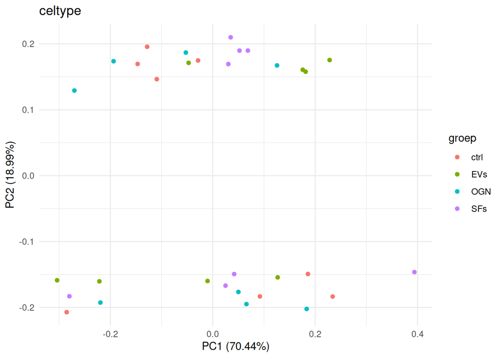

```r
autoplot(pca_result,
         data = metadata,
         colour= 'groep',
         x=1,
         y=2
         )+
  ggtitle("celtype")+
  theme_minimal()
```

# Pathway analuse

## deseq2

```r
rna_seq_data <- read.csv(
  "../data/GSE271272_rawcounts.csv")

head(rna_seq_data)
```

```
##          Sample M1_ctrl_Epcam M2_ctrl_Epcam M3_ctrl_Epcam M4_ctrl_Epcam
## 1 0610009B22Rik           266            41            79            46
## 2 0610010K14Rik            21             3             3             1
## 3 0610012G03Rik           276            41            93            74
## 4 0610030E20Rik           416            88           132            84
## 5 0610038B21Rik            16             1             4             9
## 6 0610040J01Rik           765           144           236           120
##   M1_EVs_Epcam M2_EVs_Epcam M3_EVs_Epcam M4_EVs_Epcam M1_SFs_Epcam M2_SFs_Epcam
## 1          100           59          171          277          198           14
## 2            7            2           17           24           19            2
## 3           96          113          273          304          254           30
## 4          163          106          372          494          443           36
## 5            3            1            6            6           12            1
## 6          221          170          584          661          692           75
##   M3_SFs_Epcam M4_SFs_Epcam M1_OGN_Epcam M2_OGN_Epcam M3_OGN_Epcam M4_OGN_Epcam
```

[output cut: 27 more lines]

```r
cts <- data.frame(rna_seq_data[,-1])
colnames(cts) <- colnames(rna_seq_data)[-1]
row.names(cts) <- rna_seq_data$Sample
cts <- as.matrix(cts)
```

```r
sample_names <- c("M1_ctrl_Epcam", "M2_ctrl_Epcam", "M3_ctrl_Epcam", "M4_ctrl_Epcam",
            "M1_EVs_Epcam", "M2_EVs_Epcam", "M3_EVs_Epcam", "M4_EVs_Epcam",
            "M1_SFs_Epcam", "M2_SFs_Epcam", "M3_SFs_Epcam", "M4_SFs_Epcam",
            "M1_OGN_Epcam", "M2_OGN_Epcam", "M3_OGN_Epcam", "M4_OGN_Epcam",
            "M1_ctrl_CCL", "M2_ctrl_CCL", "M3_ctrl_CCL", "M4_ctrl_CCL",
            "M1_EVs_CCL", "M2_EVs_CCL", "M3_EVs_CCL", "M4_EVs_CCL",
            "M1_SFs_CCL", "M2_SFs_CCL", "M3_SFs_CCL", "M4_SFs_CCL",
            "M1_OGN_CCL", "M2_OGN_CCL", "M3_OGN_CCL", "M4_OGN_CCL")

group <- rep(c("control", "extracellular_vesicles", "soluble_factors", "osteoglycin"), each = 4, times = 2)
type <- rep(c("epcam", "ccl"), each = 16)

metadata <- data.frame(group = factor(group), type = type)
rownames(metadata) <- sample_names

head(metadata)
```

```
##                                group  type
## M1_ctrl_Epcam                control epcam
## M2_ctrl_Epcam                control epcam
## M3_ctrl_Epcam                control epcam
## M4_ctrl_Epcam                control epcam
## M1_EVs_Epcam  extracellular_vesicles epcam
## M2_EVs_Epcam  extracellular_vesicles epcam
```

```r
dds <- DESeqDataSetFromMatrix(countData = cts,
                              colData = metadata,
                              design = ~ group)
```

```r
dds <- DESeq(dds)
control_vs_extracellular <- results(dds, contrast = c("group", "control", "extracellular_vesicles"))
control_vs_soluble <- results(dds, contrast = c("group", "control", "soluble_factors"))
extracellular_vs_soluble <- results(dds, contrast = c("group", "extracellular_vesicles", "soluble_factors"))
```

Na dat alles kan ik verder.

```r
gene_ranks_crl_extra <- control_vs_extracellular$stat
names(gene_ranks_crl_extra) <- rownames(control_vs_extracellular)
gene_ranks_crl_extra <- sort(gene_ranks_crl_extra, decreasing = T)
```

```r
gene_ranks_crl_sol <- control_vs_soluble$stat
names(gene_ranks_crl_sol) <- rownames(control_vs_soluble)
gene_ranks_crl_sol <- sort(gene_ranks_crl_sol, decreasing = T)
```

```r
gene_ranks_extra_sol <- extracellular_vs_soluble$stat
names(gene_ranks_extra_sol) <- rownames(extracellular_vs_soluble)
gene_ranks_extra_sol <- sort(gene_ranks_extra_sol, decreasing = T)
```